# Activity monitoring data analysis

Astrid Babayan

August 21, 2016

## Loading and preprocessing the data

### 1. Code for reading in the dataset and/or processing the data.

```r
library(mice)
library(VIM)
setwd("U:/R/COurse5/Week2")
df.activity<-read.csv("activity.csv")

summary(df.activity)
```

```
##      steps                date          interval
##  Min.   :  0.00   2012-10-01:  288   Min.   :   0.0
##  1st Qu.:  0.00   2012-10-02:  288   1st Qu.: 588.8
##  Median :  0.00   2012-10-03:  288   Median :1177.5
##  Mean   : 37.38   2012-10-04:  288   Mean   :1177.5
##  3rd Qu.: 12.00   2012-10-05:  288   3rd Qu.:1766.2
##  Max.   :806.00   2012-10-06:  288   Max.   :2355.0
##  NA's   :2304     (Other)   :15840
```

## What is mean total number of steps taken per day?

### 2. Histogram of the total number of steps taken each day

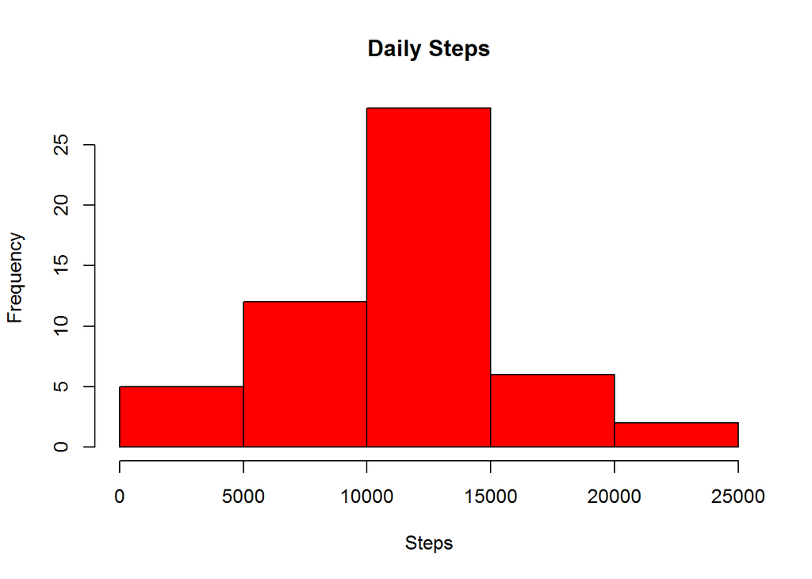

```r
daily.aggregate<-aggregate(x=df.activity$steps, by=list(date=df.activity$date), FUN=sum)

hist(daily.aggregate$x, main="Daily Steps", xlab="Steps", col="red")
```

Median daily step count is 10765.

## What is the average daily activity pattern?

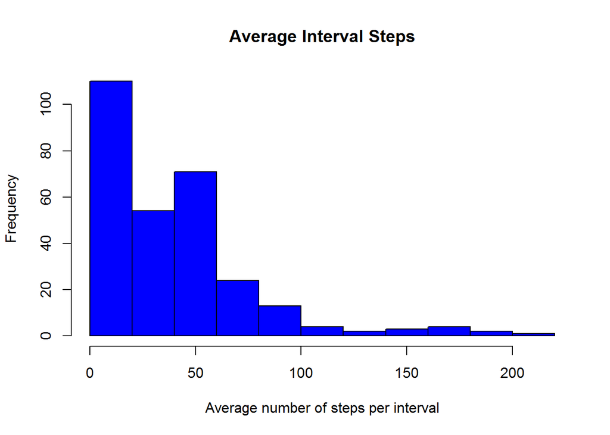

```r
interval.aggregate<-aggregate(x=df.activity$steps, by=list(interval=df.activity$interval), FUN="mean", na.rm=TRUE)

hist(interval.aggregate$x,  main="Average Interval Steps", xlab="Average number of steps per interval", col="blue")
```

### 4. Time series plot of the average number of steps taken

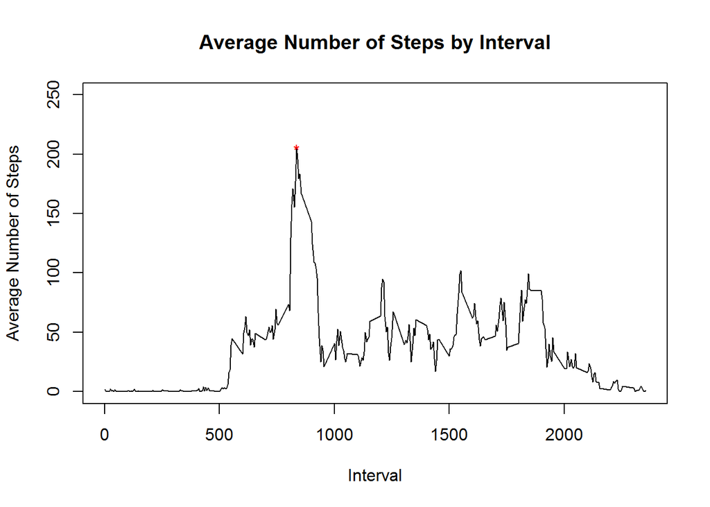

```r
plot(x=interval.aggregate$interval, y=interval.aggregate$x, type="l", xlab="Interval", ylab="Average Number of Steps", main="Average Number of Steps by Interval", ylim=c(0,250))
with(subset(interval.aggregate, x==max(interval.aggregate$x)),text(interval,x,"*", col="red"))
```

### 5. The 5-minute interval that, on average, contains the maximum number of steps

```r
maximum<-subset(interval.aggregate, x==max(interval.aggregate$x))
```

It occures at 5-minute interval number 835. The average number of steps at that interval is 206.2.

## Imputing missing values

### 6. Code to describe and show a strategy for imputing missing data

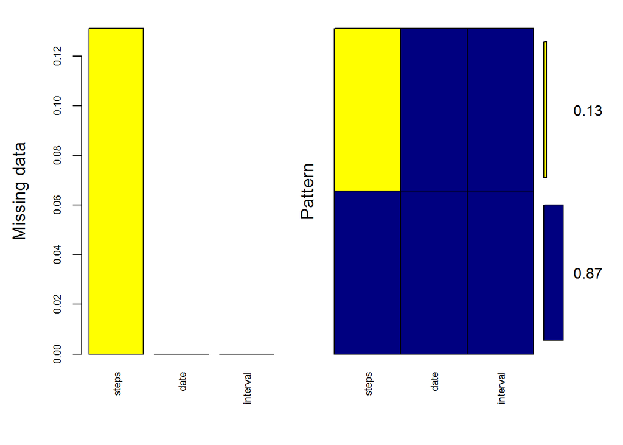

```
##
##  Variables sorted by number of missings:
##  Variable     Count
##     steps 0.1311475
##      date 0.0000000
##  interval 0.0000000
```

```r
mice_plot <- aggr(df.activity, col=c('navyblue','yellow'),
                  numbers=TRUE, sortVars=TRUE,
                  labels=names(df.activity), cex.axis=.7,
                  gap=3, ylab=c("Missing data","Pattern"))
```

There are 2304 missing values in the dataset for variable “steps”.

Missing values are imputed by using “mice” library’s pmm method (predictive mean method).

```r
imputed_Data <- mice(data = df.activity, m = 1, method = "pmm", maxit = 10, seed = 100)
imputed_df.activity<-complete(imputed_Data, 1)
```

Missing data pattern plot below confirms the imputation.

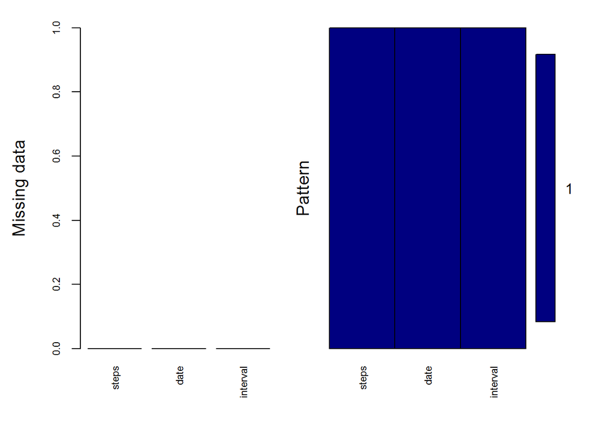

```
##
##  Variables sorted by number of missings:
##  Variable Count
##     steps     0
##      date     0
##  interval     0
```

```r
mice_plot <- aggr(imputed_df.activity, col=c('navyblue','yellow'),
                  numbers=TRUE, sortVars=TRUE,
                  labels=names(imputed_df.activity), cex.axis=.7,
                  gap=3, ylab=c("Missing data","Pattern"))
```

### 7. Histogram of the total number of steps taken each day after missing values are imputed

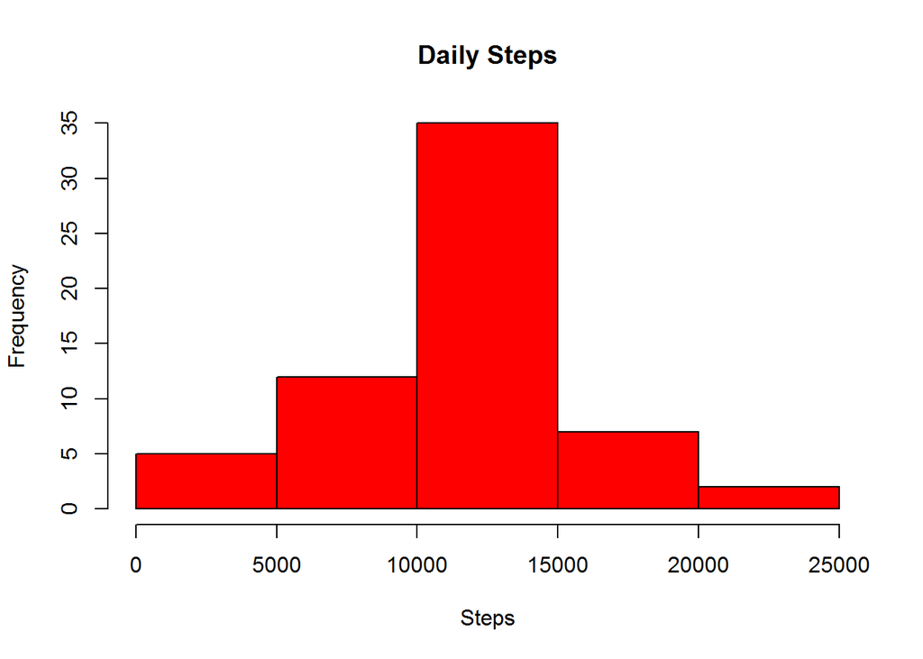

```r
imp_daily.aggregate<-aggregate(x=imputed_df.activity$steps, by=list(date=imputed_df.activity$date), FUN=sum)

hist(imp_daily.aggregate$x, main="Daily Steps", xlab="Steps", col="red")
```

Median daily step count after imputation is 11162.

## Are there differences in activity patterns between weekdays and weekends?

### 8. Panel plot comparing the average number of steps taken per 5-minute interval across weekdays and weekends

```r
#creating weekend indicator variable

imputed_df.activity$weekend<-ifelse(weekdays(as.Date(imputed_df.activity$date)) %in% c("Saturday", "Sunday"), "YES", "NO")
```

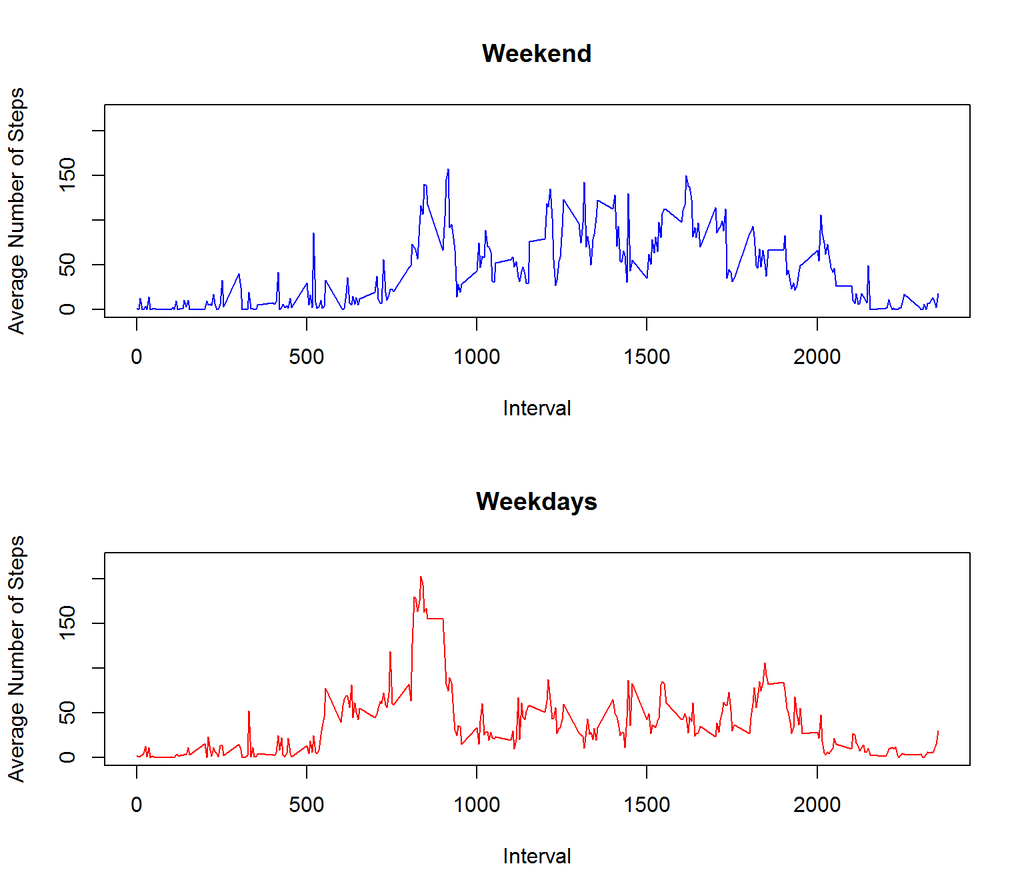

```r
#calculating average step values by intervals

imputed_daily.aggregate<-aggregate(x=imputed_df.activity$steps,
                                   by=list(interval=imputed_df.activity$interval, weekend=imputed_df.activity$weekend), FUN=mean)


par(mfrow=c(2,1))

plot(subset(imputed_daily.aggregate, weekend=="YES")$interval, subset(imputed_daily.aggregate, weekend=="YES")$x,
     type="l",
     main="Weekend",
     xlab="Interval",
     ylab="Average Number of Steps",
     ylim=c(0,220),
     col="blue")
plot(subset(imputed_daily.aggregate, weekend=="NO")$interval, subset(imputed_daily.aggregate, weekend=="NO")$x,
     main="Weekdays",
     type="l",
     xlab="Interval",
     ylab="Average Number of Steps",
     ylim=c(0,220),
     col="red")
```

Average number of steps on weekeds are lower between 500 and 1000 intervals but slightly higher on the later intervals.